# Lab 05 - Sad plots

Solutions

2022-12-14

### Load packages and data

```r
library(tidyverse)
library(dsbox)
```

#Instructors

### Exercise 1

```r
instructors_long = instructors %>%
  pivot_longer(cols=!year,
               names_to = "faculty_type",
               values_to = "value")
```

### Exercise 2

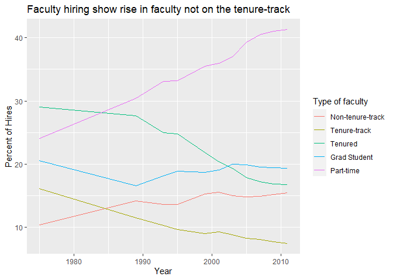

```r
instructors_long %>%
  ggplot(aes(x=year, y=value, color=faculty_type)) +
  geom_line()+
  labs(x="Year", y="Percent of Hires", title="Faculty hiring show rise in faculty not on the tenure-track")+
  scale_color_discrete(name="Type of faculty", labels = c("Non-tenure-track", "Tenure-track", "Tenured", "Grad Student", "Part-time"))
```

### Exercise 3

To emphasize part-time faculty, I will change the title and the colors to make the story easy to see.

### Exercise 4

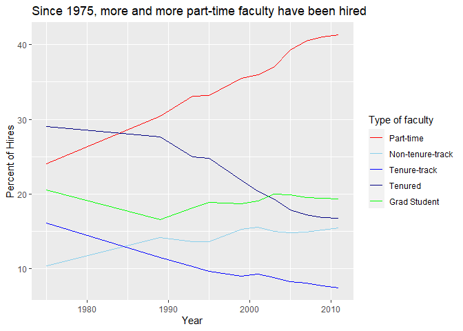

```r
instructors_long = instructors_long %>%
  mutate(faculty_type = fct_relevel(faculty_type, "part_time"))

instructors_long %>%
  ggplot(aes(x=year, y=value, color=faculty_type))+
#lwd=c(1,1.05)[(faculty_type=="part_time")+1]
  geom_line()+
  guides(lwd="none")+
  labs(x="Year", y="Percent of Hires", title="Since 1975, more and more part-time faculty have been hired")+
  scale_color_manual(name="Type of faculty",
                     values = c("red", "skyblue", "blue", "navy", "green"),
                     labels = c("Part-time","Non-tenure-track", "Tenure-track", "Tenured", "Grad Student"))
```

We could go further and grey out all but part time, but I didn’t know how to make the the labels clear. Other options are possible.

Here is a nice example solution from the TA’s lab group (J Marvald, C Hammond, and un-named coauthors):

```r
# Run the following in console to get package for labels to work
# install.packages("ggrepel")
# Then include the library in the markdown
library(ggrepel) #could be here or at the top with the other libraries
```

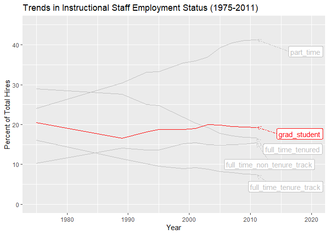

```r
# make new df for labels
label_instructors =
  instructors_long %>%
  mutate(percent = value) #change of variable name to match their code

# create label for last year only
label_instructors$label = NA_integer_
label_instructors$label[which(label_instructors$year == max(label_instructors$year))] = label_instructors$faculty_type[which(label_instructors$year == max(label_instructors$year))]
label_instructors$label = factor(label_instructors$label, labels=levels(label_instructors$faculty_type))

# use new df with labels to plot
label_instructors %>%
  ggplot(aes(x = year, y = percent, color = faculty_type)) +
  geom_line() +
  xlim(1975, 2020) +
  ylim(0, 45) +
  geom_label_repel(aes(label = label),
                   nudge_x = 9,
                   nudge_y = -3,
                   force = 4,
                   arrow = arrow(length = unit(0.02, "npc")),
                   segment.linetype = 4,
                   na.rm = TRUE) +
  theme(legend.position = "none") +
  scale_color_manual(values = c("grey", "grey", "grey", "grey", "red")) +
  labs(x = "Year", y = "Percent of Total Hires", col = "Type of Hire",
       title = "Trends in Instructional Staff Employment Status (1975-2011)")
```

#Fisheries

The following solution comes from the lab group “Damson” from last year. I think a lot of you this year did some changes even more impressive than this, but there are a lot of reasonable answers as long as you wrote out the thought process in Ex. 5.